# 5. ARMA model

# (5-1) ARMA(p,q) Model"

[Nao Mimoto](https://nmimoto.github.io/) - [Dept. of Statistics](http://www.uakron.edu/stat/) : [The University of Akron](http://www.uakron.edu)

[TS Class Web Page](https://nmimoto.github.io/477/) – [R resource page](https://nmimoto.github.io/R/)

# 1. ARMA(p,q) Model

### ARMA(1,1)

- ARMA(1,1) model is defined as
  $${\large
  X_t - \phi_1 X_{t-1} \hspace{3mm} = \hspace{3mm} e_t + \theta_1 e_{t-1}
  }$$
  where $e_t\sim WN(0,\sigma^2)$.
- Using the backward operator, this is same as
  $${\large
  (1- \phi_1 B) \, X_t \hspace{3mm} = \hspace{3mm} (1 + \theta_1 B) \, e_t
  }$$
  $${\large
  \Phi(B) \, X_t \hspace{3mm} = \hspace{3mm} \Theta(B) \, e_t
  }$$

## ARMA(p,q)

$${\large
X_t - \phi_1 X_{t-1} - \phi_1 X_{t-1} - \cdots - \phi_p X_{t-p}
\hspace{3mm} = \hspace{3mm} e_t + \theta_1 e_{t-1} + \theta_2 e_{t-2} + \cdots + \theta_q e_{t-q}
}$$
$${\large
(1- \phi_1 B - \phi_2 B^2 - \cdots - \phi_p B^p) \,\, X_t
\hspace{3mm} = \hspace{3mm} (1 + \theta_1 B + \theta_2 B^2 + \cdots + \theta_p B^p) \,\, e_t
}$$
$${\large
\Phi(B) \,\, X_t \hspace{3mm} = \hspace{3mm} \Theta(B) \,\, e_t
}$$

### ARMA(3,2)

- For example, ARMA(3,2) would look like
  $${\large
  X_t - \phi_1 X_{t-1} - \phi_2 X_{t-2} - \phi_3 X_{t-3} \hspace{3mm} = \hspace{3mm} e_t + \theta_1 e_{t-1} + \theta_2 e_{t-2}
  }$$

  $${\large
  (1- \phi B - \phi_2 B^2 - \phi_3 B^3) \, X_t \hspace{3mm} = \hspace{3mm} (1 + \theta B + \theta_2 B^2) \, e_t
  }$$

  $${\large
  \Phi(B) X_t \hspace{3mm} = \hspace{3mm} \Theta(B) e_t
  }$$

## Causal Representation of ARMA(p,q)

- If the AR characteristic polinomial $\Phi(z)$ has all the root outside of the unit circle, we can represent ARMA($p,q$) process as causal,
  $${\large
  X_t \hspace{3mm} = \hspace{3mm} \sum_{i=0}^\infty \psi_i \, e_{t-i}
  }$$
  with absolutely summable sequence $\psi_i$. The process is stationary.

## Invertible Representation of ARMA(p,q)

- If the MA characteristic polinomial $\Theta(z)$ has all the root outside of the unit circle, we can represent ARMA($p,q$) process as invertible,
  $${\large
  e_t \hspace{3mm} = \hspace{3mm} \sum_{i=0}^\infty \pi_i \, X_{t-i}
  }$$
  with absolutely summable sequence $\pi_i$.
- We assume that all ARMA($p,q$) are causal, and invetible.  
  Again, nothing is lost in this assumption.

## Theoretical ACF and ACVF of ARMA

- Now both ACF and PACF will go down

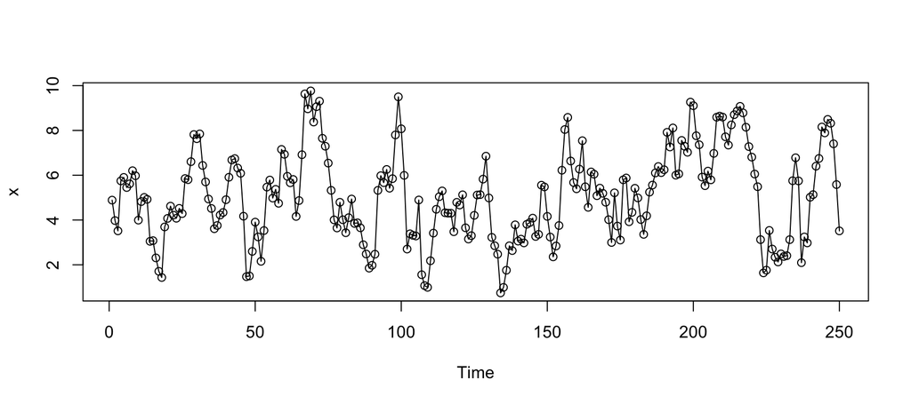

```r
  phis   <- c(.4, .2)
  thetas <- c(.6, .2)

  # sign is like [Brockwell]:  (1-phi B) X_t = (1+theta B) e_t
  Th.acf  <- ARMAacf(ar=phis, ma=thetas, lag.max=20)           # Theoretical ACF
  Th.pacf <- ARMAacf(ar=phis, ma=thetas, lag.max=20, pacf=T)   # Theoretical PACF
  #--- Basic Simulation with ARMA(p,q) ---
  mu <- 5
  x  <- arima.sim(n = 250, list(ar =phis,   ma = thetas )) + mu   # Simulate ARMA(2,2)

  plot(x, type="o");
```

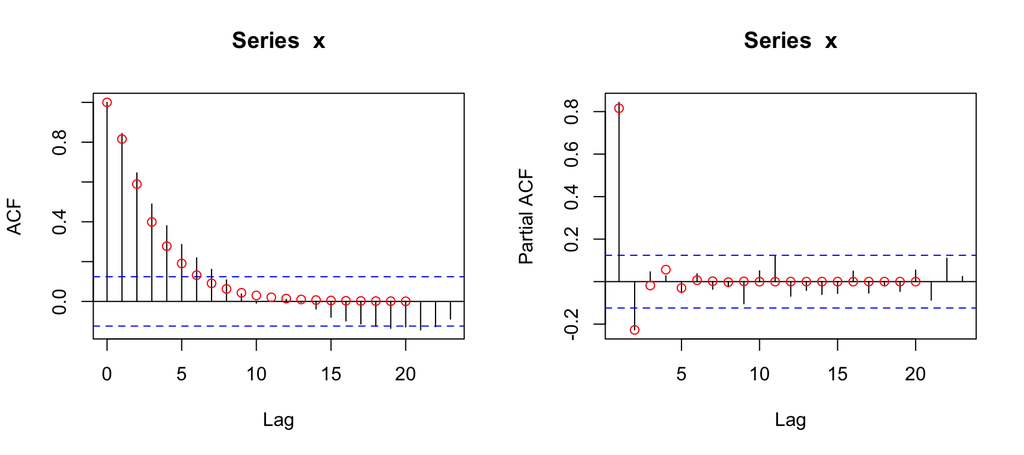

```r
  layout(matrix(1:2, 1, 2))
  acf(x);   lines(0:20, Th.acf,  type='p', col="red")      # sample ACF;  Theo ACF
  pacf(x);  lines(1:20, Th.pacf, type='p', col="red")      # sample PACF; Theo PACF
```

```r
  layout(1)
```

# 2. Fitting ARMA(p,q) Model Workflow

### 0. Assumption

- Start with Stationary Data.
- Assuming ACF and PACF showing some autocorrelation.

### 1. Order selection

- Sometimes, shapes of ACF, and PACF is informative.
- Use **auto.arima()** to select best value for $p$ and $q$ using **AICc(default)**, AIC, BIC, Log Likelihood.
- **Stepwise** method (default) vs All Combination method. All Combo is better. Turn the stepwise off by **stepwise=FALSE**.
- make sure option d=0 is used. Or you get (p,d,q)=(p,0,q).
- Use **Arima( order=c(p,0,q) )** to fit specific model.

### 2. Parameter Estimation and Significance Check

- Maximum Likelihood method
- CSS method
- **CSS-MLE** method (default)
- **Approximation** is used if $n>150$. Better to turn off. Use **approximation=FALSE**.
- Yule-Walker (AR only)
- Check for parameter significance
- With mean or without mean

### 3. Residual Analysis (Randomness.tests() function)

- Ljung-Box test
- McLeod-Li test
- Jaque-Bera test

### 4. Forecast

- Rolling 1-step prediction (retrospective)
- Static h-step prediction (prospective)

### 5. Model Diagnostics

- Prediction power as expected?
- When there is more than 1 candiate, is one model significantly better than the other? (prediction power, interpretability, simplicity)

# 3. Order Selection of ARMA(p,q) model

## Order Selection

- Plot of ACF and PACF
- AICc and AIC
- BIC
- Log-Likelihood

## AICc

- Bias-corrected version of AIC, suggested by Hurvich and Tsai (1989)
  $${\large
  \mbox{AICC} = - 2 \log(\mbox{Max Likehood}) + \frac{2(k+1)(k+2)}{n-k-2}
  }$$
  where $k=p+q+1$ if non-zero mean is in the model, and $k=p+q$ if no mean is in the model.
- Compare this to AIC, which was designed to be an approximately unbiased estimate of the Kullback–Leibler index of the fitted model relative to the true model:
  $${\large
  \mbox{AIC} = - 2 \log(\mbox{Max Likehood}) + 2k
  }$$
- See Brockwell 5.5.2 for more.

## BIC

Bayesian Information Criteria

$${\large
\mbox{BIC} = - 2 \log(\mbox{Max Likehood}) + k \log(n)
}$$

where $k=p+q+1$ if non-zero mean is in the model, and $k=p+q$ if no mean is in the model.

## auto.arima() in forecast package

- **auto.arima()** picks best $p,q$ using **AICc** and **Stepwise** method as default.
- It will use stepwise selection by default. Setting **stepwise=FALSE** option will force the function to look through all the combinations.
- For example, **max.order=5, stepwise=FALSE** option will force the function to search all the models in between AR(5) to MA(5).
- Use **trace=TRUE** option to see values of AICc for all the models fitted by the function.
- Use **?auro.arima** to open the help page for documentation.

## Simulation Study: Is AICc better?

How much better is AICC over AIC? In what scenario?

- Simulate ARMA(2,1) with non-zero mean
- Pick ARMA(p,q) model based on AICc, AIC, BIC.
- Repeat 1000 times, see how many times each criteria picked right $p$.

```r
  library(forecast)   #if not installed, do:  install.packages("forecast")


  # initialize the object that saves result
  Result1 <- Result2 <- Result3 <- matrix(0, 1000, 7)
  Result4 <- Result5 <- Result6 <- matrix(0, 1000, 7)
  for (i in 1:1000){
    Y <- arima.sim(list(ar = c(.6, -.6), ma=c(.8) ), 100 ) + 10     # case 1
    #Y <- arima.sim(list(ar = c(.6,  .3), ma=c(.5) ), 100 ) + 10      # case 2

    #- picks model based on AICC, AIC, and BIC
    Fit1 <- auto.arima(Y, max.order=6, max.d=0, max.D=0,  ic=c("aicc"))
    Fit2 <- auto.arima(Y, max.order=6, max.d=0, max.D=0,  ic=c("aic"))
    Fit3 <- auto.arima(Y, max.order=6, max.d=0, max.D=0,  ic=c("bic"))

    #- all combo method (takes time)
    Fit4 <- auto.arima(Y, max.order=6, max.d=0, max.D=0,  ic=c("aicc"), stepwise=FALSE)

    print(i)   #- print order on screen (optional)

    Result1[i,] <- Fit1$arma   # checks if it picked ARMA(2,1) with mean
    Result2[i,] <- Fit2$arma
    Result3[i,] <- Fit3$arma
    Result4[i,] <- Fit4$arma
  }

  R1 <- apply( Result1, 1, function(x){ setequal(x, c(2,1,0,0,1,0,0)) } )
  R2 <- apply( Result2, 1, function(x){ setequal(x, c(2,1,0,0,1,0,0)) } )
  R3 <- apply( Result3, 1, function(x){ setequal(x, c(2,1,0,0,1,0,0)) } )
  R4 <- apply( Result4, 1, function(x){ setequal(x, c(2,1,0,0,1,0,0)) } )
  c(mean(R1),  mean(R2),  mean(R3), mean(R4))

  # Results
  # AICc   AIC    BIC    AICc w All
  # 0.867  0.835  0.943  0.716        for Case 1  ar=(.6, -.6) ma=c(.8) mu=10
  # 0.352  0.374  0.172  0.293        for Case 2  ar=(.6,  .5) ma=c(.8) mu=10
```

- In this two cases Stepwise method picked correct $(p,q)$ more frequently than All Combination method.
- Still, use **stepwise=FALSE** when time allows.

# 3. Example: Annual Copper Price

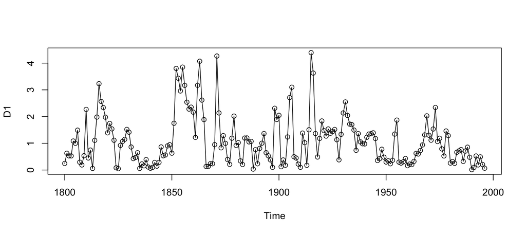

```r
  library(forecast)     # load forecast package

  D  <- read.csv("https://nmimoto.github.io/datasets/copper.csv")
  D1 <- ts(D[,2], start=c(1800,1), freq=1)
  plot(D1, type='o')
```

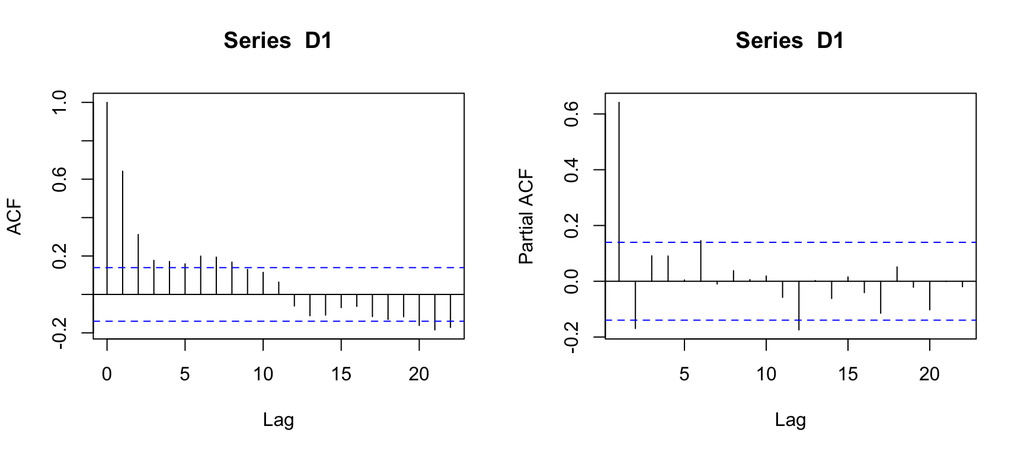

```r
  layout(matrix(1:2, 1, 2))
  acf(D1)
  pacf(D1)
```

```r
  layout(1)


  Fit01 <- auto.arima(D1, d=0  )       # search for best ARMA(p,q) using AICc (default)
  Fit01
```

```
## Series: D1
## ARIMA(1,0,3) with non-zero mean
##
## Coefficients:
##          ar1      ma1      ma2      ma3    mean
##       0.8695  -0.0925  -0.2958  -0.1809  1.0607
## s.e.  0.0865   0.1129   0.0921   0.0751  0.1590
##
## sigma^2 estimated as 0.4809:  log likelihood=-205.24
## AIC=422.47   AICc=422.91   BIC=442.17
```

```r
  #- Search for best ARMA(p,q) using stepwise method (default)
  Fit02 <- auto.arima(D1, trace=TRUE, d=0  )
```

```
##
##  Fitting models using approximations to speed things up...
##
##  ARIMA(2,0,2) with non-zero mean : 423.7516
##  ARIMA(0,0,0) with non-zero mean : 530.4825
##  ARIMA(1,0,0) with non-zero mean : 426.7567
##  ARIMA(0,0,1) with non-zero mean : 443.946
##  ARIMA(0,0,0) with zero mean     : 700.8463
##  ARIMA(1,0,2) with non-zero mean : 424.0844
##  ARIMA(2,0,1) with non-zero mean : 425.3012
##  ARIMA(3,0,2) with non-zero mean : Inf
##  ARIMA(2,0,3) with non-zero mean : 422.5371
##  ARIMA(1,0,3) with non-zero mean : 422.4479
##  ARIMA(0,0,3) with non-zero mean : 425.3453
##  ARIMA(1,0,4) with non-zero mean : 423.2063
##  ARIMA(0,0,2) with non-zero mean : 423.4821
##  ARIMA(0,0,4) with non-zero mean : 423.9759
##  ARIMA(2,0,4) with non-zero mean : 424.7047
##  ARIMA(1,0,3) with zero mean     : 427.7261
##
##  Now re-fitting the best model(s) without approximations...
##
##  ARIMA(1,0,3) with non-zero mean : 422.9125
##
##  Best model: ARIMA(1,0,3) with non-zero mean
```

```r
  Fit02
```

```
## Series: D1
## ARIMA(1,0,3) with non-zero mean
##
## Coefficients:
##          ar1      ma1      ma2      ma3    mean
##       0.8695  -0.0925  -0.2958  -0.1809  1.0607
## s.e.  0.0865   0.1129   0.0921   0.0751  0.1590
##
## sigma^2 estimated as 0.4809:  log likelihood=-205.24
## AIC=422.47   AICc=422.91   BIC=442.17
```

```r
  #- Search for best ARMA(p,q) using all combo method
  Fit03 <- auto.arima(D1, max.order=5, stepwise=FALSE, trace=TRUE, d=0  )
```

```
##
##  Fitting models using approximations to speed things up...
##
##  ARIMA(0,0,0) with zero mean     : 700.8463
##  ARIMA(0,0,0) with non-zero mean : 530.4825
##  ARIMA(0,0,1) with zero mean     : 558.2574
##  ARIMA(0,0,1) with non-zero mean : 443.946
##  ARIMA(0,0,2) with zero mean     : 494.8108
##  ARIMA(0,0,2) with non-zero mean : 423.4821
##  ARIMA(0,0,3) with zero mean     : 486.0749
##  ARIMA(0,0,3) with non-zero mean : 425.3453
##  ARIMA(0,0,4) with zero mean     : 469.1278
##  ARIMA(0,0,4) with non-zero mean : 423.9759
##  ARIMA(0,0,5) with zero mean     : 469.7398
##  ARIMA(0,0,5) with non-zero mean : 425.9194
##  ARIMA(1,0,0) with zero mean     : 447.9218
##  ARIMA(1,0,0) with non-zero mean : 426.7567
##  ARIMA(1,0,1) with zero mean     : 449.3997
##  ARIMA(1,0,1) with non-zero mean : 422.2187
##  ARIMA(1,0,2) with zero mean     : 434.144
##  ARIMA(1,0,2) with non-zero mean : 424.0844
##  ARIMA(1,0,3) with zero mean     : 427.7261
##  ARIMA(1,0,3) with non-zero mean : 422.4479
##  ARIMA(1,0,4) with zero mean     : 428.9934
##  ARIMA(1,0,4) with non-zero mean : 423.2063
##  ARIMA(2,0,0) with zero mean     : 450.3632
##  ARIMA(2,0,0) with non-zero mean : 424.0151
##  ARIMA(2,0,1) with zero mean     : 451.2702
##  ARIMA(2,0,1) with non-zero mean : 425.3012
##  ARIMA(2,0,2) with zero mean     : Inf
##  ARIMA(2,0,2) with non-zero mean : 423.7516
##  ARIMA(2,0,3) with zero mean     : 427.8439
##  ARIMA(2,0,3) with non-zero mean : 422.5371
##  ARIMA(3,0,0) with zero mean     : 443.7924
##  ARIMA(3,0,0) with non-zero mean : 425.0625
##  ARIMA(3,0,1) with zero mean     : 430.2233
##  ARIMA(3,0,1) with non-zero mean : 424.6783
##  ARIMA(3,0,2) with zero mean     : 448.4045
##  ARIMA(3,0,2) with non-zero mean : Inf
##  ARIMA(4,0,0) with zero mean     : 439.7487
##  ARIMA(4,0,0) with non-zero mean : 426.3368
##  ARIMA(4,0,1) with zero mean     : 432.6415
##  ARIMA(4,0,1) with non-zero mean : 426.0786
##  ARIMA(5,0,0) with zero mean     : 440.886
##  ARIMA(5,0,0) with non-zero mean : 429.1836
##
##  Now re-fitting the best model(s) without approximations...
##
##
##
##
##  Best model: ARIMA(1,0,1) with non-zero mean
```

```r
  Fit03
```

```
## Series: D1
## ARIMA(1,0,1) with non-zero mean
##
## Coefficients:
##          ar1     ma1    mean
##       0.4938  0.2694  1.0771
## s.e.  0.0881  0.0938  0.1229
##
## sigma^2 estimated as 0.486:  log likelihood=-207.24
## AIC=422.49   AICc=422.7   BIC=435.62
```

```r
  Arima(D1, order=c(2, 0, 1))
```

```
## Series: D1
## ARIMA(2,0,1) with non-zero mean
##
## Coefficients:
##          ar1      ar2     ma1    mean
##       0.5383  -0.0340  0.2279  1.0775
## s.e.  0.2447   0.1722  0.2357  0.1214
##
## sigma^2 estimated as 0.4884:  log likelihood=-207.23
## AIC=424.45   AICc=424.76   BIC=440.87
```

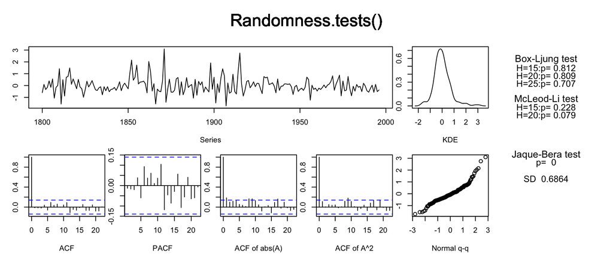

```
##   B-L test H0: the series is uncorrelated
##   M-L test H0: the square of the series is uncorrelated
##   J-B test H0: the series came from Normal distribution
##   SD         : Standard Deviation of the series
```

```
##       BL15  BL20  BL25  ML15  ML20 JB    SD
## [1,] 0.812 0.809 0.707 0.228 0.079  0 0.686
```

```r
  source('https://nmimoto.github.io/R/TS-00.txt')    # load Randomness.tests()
  Randomness.tests(Fit01$resid)
```

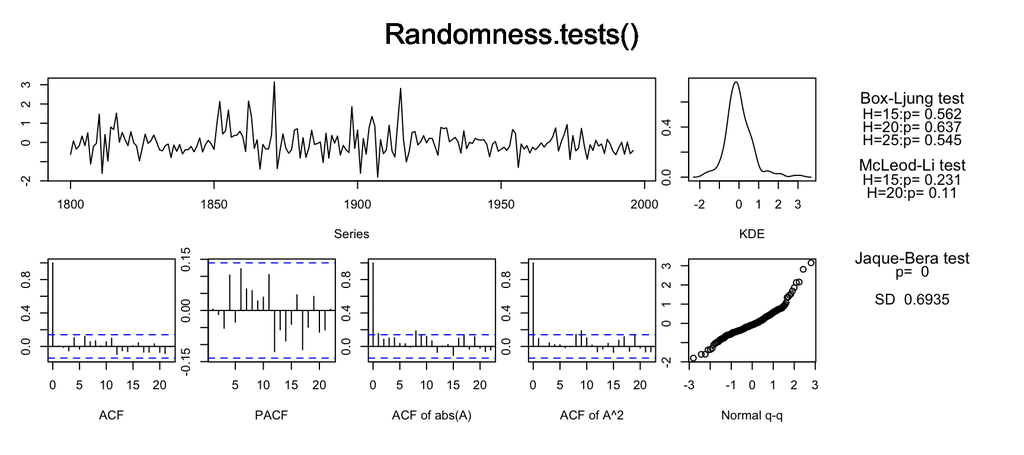

```
##   B-L test H0: the series is uncorrelated
##   M-L test H0: the square of the series is uncorrelated
##   J-B test H0: the series came from Normal distribution
##   SD         : Standard Deviation of the series
```

```
##       BL15  BL20  BL25  ML15 ML20 JB    SD
## [1,] 0.562 0.637 0.545 0.231 0.11  0 0.694
```

```r
  Randomness.tests(Fit03$resid)
```

### Fitting copper data with AR only and MA only

```r
  Fit2 <- Arima(D1, order=c(3,0,0))   # Force to fit AR(3):  order=c(p, d, q)
  Fit2
```

```
## Series: D1
## ARIMA(3,0,0) with non-zero mean
##
## Coefficients:
##          ar1      ar2     ar3    mean
##       0.7709  -0.2412  0.0948  1.0745
## s.e.  0.0709   0.0880  0.0708  0.1300
##
## sigma^2 estimated as 0.4859:  log likelihood=-206.73
## AIC=423.46   AICc=423.77   BIC=439.87
```

```r
  Fit3 <- Arima(D1, order=c(0,0,3))   # Force to fit MA(q): order=c(p, d, q)
  Fit3
```

```
## Series: D1
## ARIMA(0,0,3) with non-zero mean
##
## Coefficients:
##          ma1     ma2     ma3    mean
##       0.7794  0.3352  0.0311  1.0807
## s.e.  0.0707  0.0777  0.0668  0.1055
##
## sigma^2 estimated as 0.4895:  log likelihood=-207.46
## AIC=424.91   AICc=425.23   BIC=441.33
```

# Summary

### $\cdot$ Shape of ACF and PACF of ARMA(p,q) …..

### $\cdot$ Workflow for ARMA(p,q) is listed above.

### $\cdot$ auto.arima() chooses p,q for ARMA(p,q) based on ….

### $\cdot$ auto.arima() uses Stepwise (not All Combo) method by default.

### $\cdot$ Whenever we have time we should use All Combo method. (Code for that is **stepwise=FALSE**)

### $\cdot$ auto.arima() uses Approximation method by default when $n$ is greater than 150.

### $\cdot$ Whenever we have time we should turn it off method. (Code for that is **approximation=FALSE**)

### $\cdot$ Arima() does not use approximation even when $n$ is greater than 150.

[TS Class Web Page](https://nmimoto.github.io/477/index.html) – [R resource page](https://nmimoto.github.io/R/index.html)